# regression_analysis

2023-04-06

```r
#install.packages('corrplot')
#install.packages('xts')
library(corrplot)
library(xts)
library(vctrs)
library(rlang)
library(kernlab)
library(crypto2)
library('lubridate')
library('dplyr')
library(reshape2)
library(glue)
library(qcc)
library(tidyverse)
library(data.table)
library(ggplot2)
library(RcppRoll)
library(Rcpp)
data.daily <- read.csv('../Data/data_daily.csv')[,-1]
data.hourly <- read.csv('../Data/data_hourly.csv')[,-1]
```

```r
head(data.daily)
```

```
##          day    open    high     low   close     volume  market_cap
## 1 2017-08-01 2871.30 2921.35 2685.61 2718.26 1324669952 44804603885
## 2 2017-08-02 2727.13 2762.53 2668.59 2710.67 1094950016 44684649516
## 3 2017-08-03 2709.56 2813.31 2685.14 2804.73  804796992 46239970790
## 4 2017-08-04 2806.93 2899.33 2743.72 2895.89 1002120000 47749461443
## 5 2017-08-05 2897.63 3290.01 2874.83 3252.91 1945699968 53643452554
## 6 2017-08-06 3257.61 3293.29 3155.60 3213.94 1105030016 53006426108
##   total_tweets positive_tweets negative_tweets neutral_tweets sent_negatives
## 1        30802            6471            4701          12089     -0.4108433
## 2        23726            4734            2732           9063     -0.3699487
## 3        25111            5351            3233           9806     -0.3864231
## 4        21863            4150            2703           7959     -0.4075716
## 5        22123            6258            2115           8731     -0.4055540
## 6        15469            3754            2190           6161     -0.3956284
##   Sent_positives total_reddit positive_reddit negative_reddit neutral_reddit
```

[output cut: 125 more lines]

```r
head(data.hourly)
```

```
##              datetime        day    open    high     low   close volume..btc.
## 1 2017-08-01 00:00:00 2017-08-01 2855.81 2863.06 2823.00 2825.92       184.02
## 2 2017-08-01 01:00:00 2017-08-01 2823.01 2860.02 2821.01 2853.38        77.30
## 3 2017-08-01 02:00:00 2017-08-01 2846.27 2858.04 2837.31 2841.60       135.83
## 4 2017-08-01 03:00:00 2017-08-01 2841.84 2863.88 2837.73 2862.93       143.20
## 5 2017-08-01 04:00:00 2017-08-01 2862.92 2876.00 2848.11 2874.99       222.53
## 6 2017-08-01 05:00:00 2017-08-01 2872.03 2929.17 2865.01 2900.00       415.97
##   volume..currency. Compound_Score total_tweets negative_tweets positive_tweets
## 1          522951.0     0.08289332         1027             139             347
## 2          219605.2     0.05315978          778             111             193
## 3          386739.2     0.12425080          836              89             273
## 4          408360.0    -0.02103650          984             250             236
## 5          637045.9     0.05543746          751             114             195
## 6         1208323.9     0.09344372          842             120             286
##   neutral_tweets Sent_Negatives Sent_Positives Count_News Count_Bots
```

[output cut: 132 more lines]

Now, lets drop the rows that have no information in the close column (due to the missing price data in the twitter input data. This was addressed in the data prep Rmd file.)

```r
data.hourly <-data.hourly[is.na(data.hourly$close) == F,]

data.hourly$datetime <- ymd_hms(data.hourly$datetime)
data.hourly$day <- ymd(data.hourly$day)

data.daily$day <- ymd(data.daily$day)
```

# Data Analysis

As part of our analysis, we want to try different time-shifting intervals. i.e. does the price of bitcoin at time *t* depend on the sentiment at time *t-n* where n is the number of period back we shift. To faciliate this, we will write a function that takes in a dataframe, and shifts the closing price of bitcoin backwards *n* periods, and returns a new data frame. This way, when we look at one row of data, we can see how the sentiment of reddit comments and tweets impact the price n periods from now.

```r
shift_df <- function(df, n){
  dfc <- data.table(copy(df))
  cols = c("close")
  anscols = paste("lead", cols, sep="_")

  dfc[order(day), (anscols) := shift(.SD, n, type="lead"), .SDcols=cols]
  dfc <- dfc %>% mutate(price_dif = lead_close - close)
  dfc <- dfc %>% mutate(price_dif_percent = round((lead_close/close) - 1,4))
  dfc <- dfc %>% mutate(price_dir = ifelse(price_dif >=0, 1,0))
  dfc <- dfc[1:(nrow(dfc)-n),]
  dfc

}
```

Now, we want to also aggregate hour independent data points back *d* amount of days. This allows us to answer the following: How does the sentiment over the last *d* days/hours impact the price of Bitcoin *n* days/hours from now?

Lets write another function that can do this transformation for us.

```r
agg_lag_df <- function(df, d){

  cols <- colnames(df)
  cols <- cols[! cols %in% c('close','lead_close')]
  e <- nrow(df)
  print(e)
  for (c in cols){
  vname <- glue('{c}')
    df <- df %>%

        mutate( !!vname := roll_sum(.data[[c]], d, align = "right", fill = NA))
  }

  df <- df[d + 1:(e-d),]
  df
}
```

# Plotting some data

First, lets write a function that takes in a the columns we want to chart, scales them to have a mean of 0 and standard deviation of 1, and plots them against each other.

```r
plot_scaled_data <- function(df, y_cols, x_col, title, t){

  df<- data.frame(df)

  df[,y_cols] <- scale(df[,y_cols])
  df <- cbind(df[,x_col],df[,y_cols])
  colnames(df)[1] <- x_col
  df <- data.table(df)
  df <- melt(df, id.vars = x_col)
  plt <- ggplot(df,
                aes(x = .data[[x_col]], y = value, color = variable)) +
         ggtitle(title)

  if (t == 'line') {
    plt = plt + geom_line()
  } else if (t == 'scatter'){
    plt = plt + geom_point()

  }
  plt
}
```

## Sentiment Rating (Tweets) vs. Price

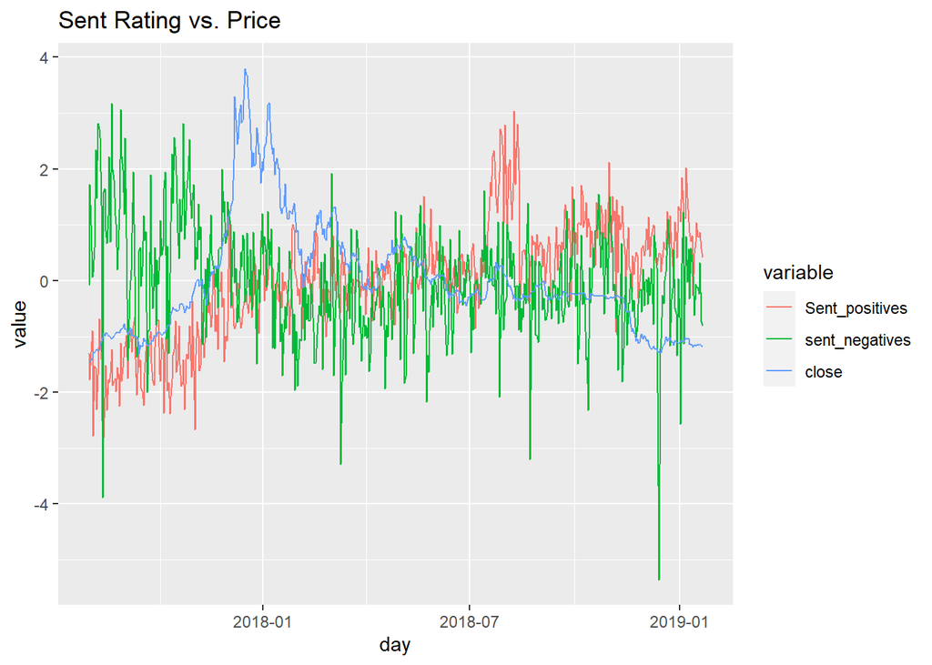

```r
cols <- c('Sent_positives',
          "sent_negatives",
          'close'
          )
data.daily$day <- ymd(data.daily$day)
plot_scaled_data(data.daily, cols, 'day', 'Sent Rating vs. Price', 'line')
```

```r
#data.daily[,cols]
```

## Sentiment mix vs. Price

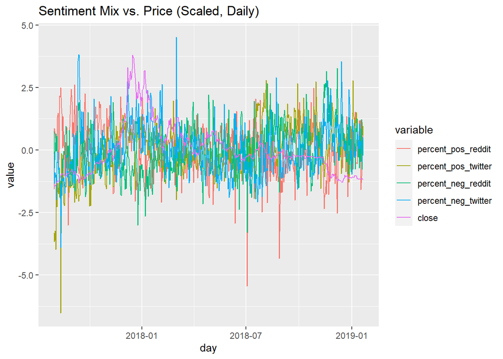

```r
df <- data.daily


cols <- c('percent_pos_reddit',
          "percent_pos_twitter",
          'percent_neg_reddit',
          'percent_neg_twitter',
          'close')
plot_scaled_data(data.daily, cols, 'day', 'Sentiment Mix vs. Price (Scaled, Daily)', 'line')
```

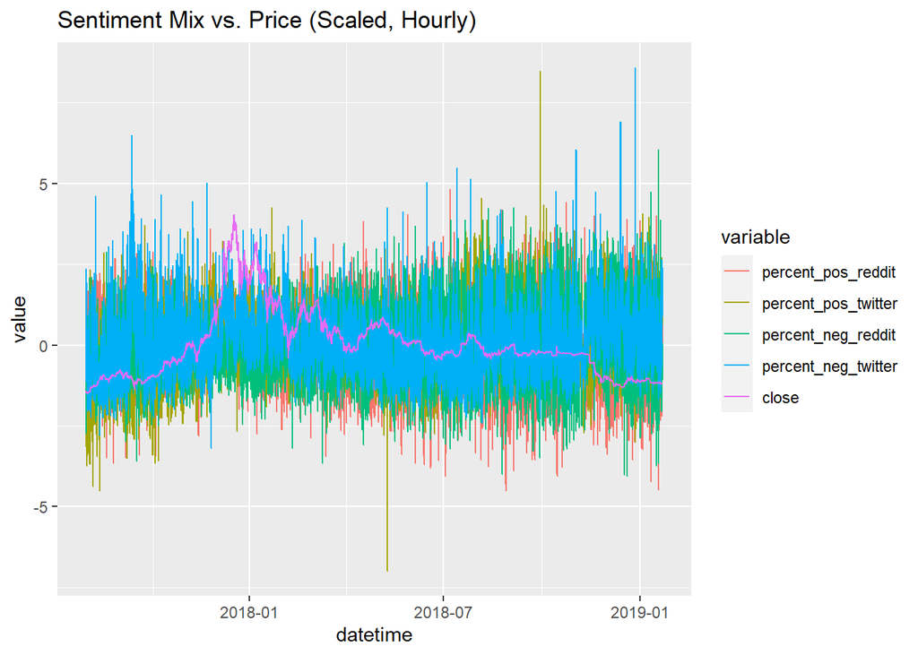

```r
df <- data.hourly
cols <- c('percent_pos_reddit',
          "percent_pos_twitter",
          'percent_neg_reddit',
          'percent_neg_twitter',
          'close')
plot_scaled_data(df, cols, 'datetime', 'Sentiment Mix vs. Price (Scaled, Hourly)', 'line')
```

Visually inspecting this, it does not appear that the mix of positive/negative comments/tweets appears to fluctuate in any meaningful way with the price. We expected to see that when price is climing, the percent mix of positive comments/Tweets about bitcoin would also increase. However, this was not the case.

## # of Comments/Tweets vs. Price

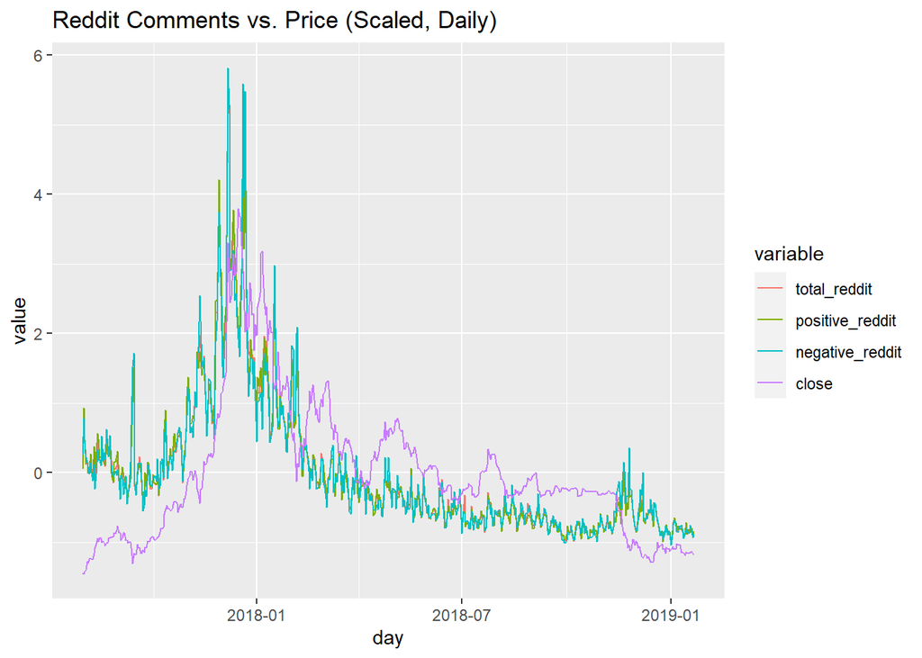

```r
df <- data.daily
cols <- c('total_reddit',
          "positive_reddit",
          'negative_reddit',
          'close')
plot_scaled_data(df, cols, 'day', 'Reddit Comments vs. Price (Scaled, Daily)', 'line')
```

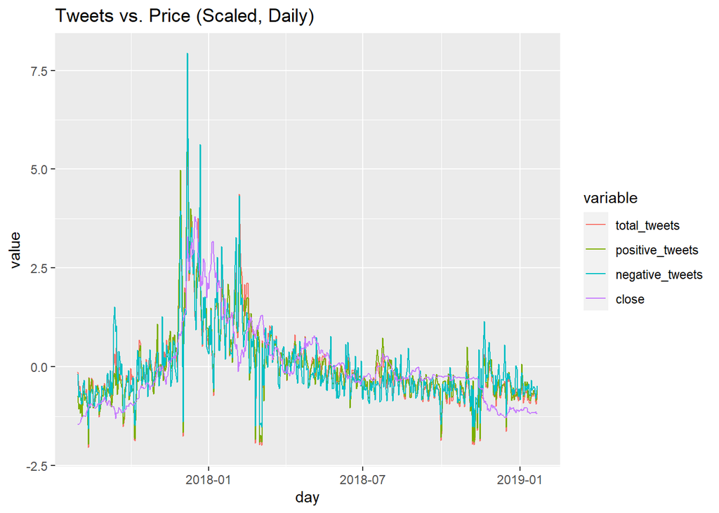

```r
cols <- c('total_tweets',
          "positive_tweets",
          'negative_tweets',
          'close')
plot_scaled_data(df, cols, 'day', 'Tweets vs. Price (Scaled, Daily)', 'line')
```

[figure not shown]

```r
df <- data.hourly

cols <- c('total_reddit',
          "positive_reddit",
          'negative_reddit',
          'close')
plot_scaled_data(df, cols, 'datetime', 'Reddit Comments vs. Price (Scaled, Hourly)', 'line')
```

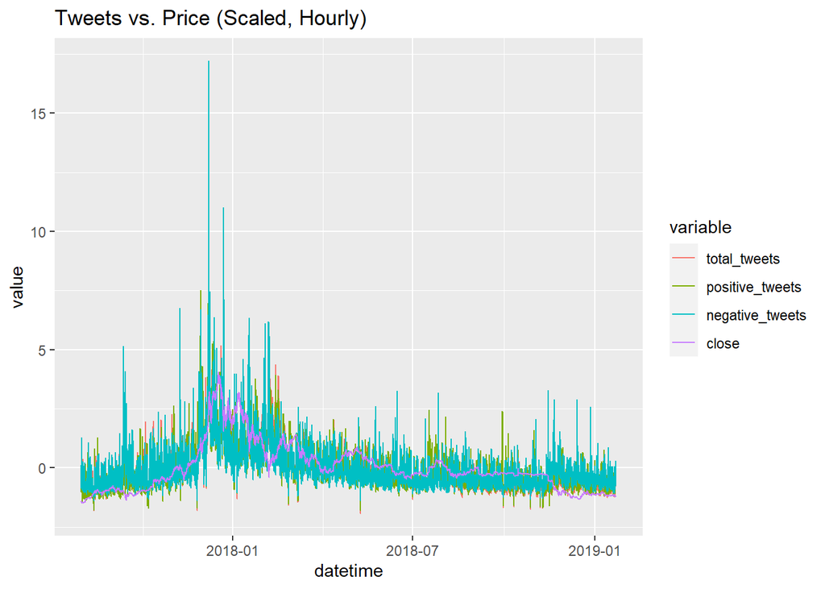

```r
cols <- c('total_tweets',
          "positive_tweets",
          'negative_tweets',
          'close')
plot_scaled_data(df, cols, 'datetime', 'Tweets vs. Price (Scaled, Hourly)', 'line')
```

These charts are particularly interesting, it seems that the total number of tweets and comments, regardless of whether they are positive or negative, seems to very closely track the price of bitcoin. Let’s plot the total tweet/comment activity against the price of bitcoin on each day/hour and see if there appears to be any correlation.

```r
df <- data.daily

df <- agg_lag_df(df,30)
```

```
## [1] 539
```

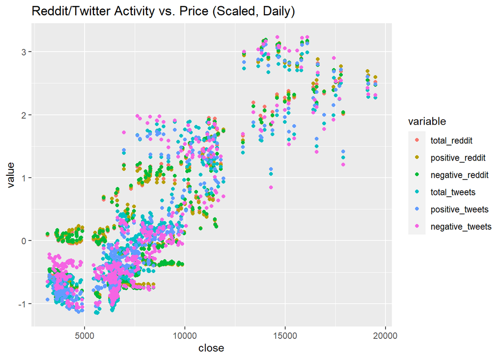

```r
cols <- c('total_reddit',
          "positive_reddit",
          'negative_reddit',
          'total_tweets',
          "positive_tweets",
          'negative_tweets'
          )
plot_scaled_data(df, cols, 'close', 'Reddit/Twitter Activity vs. Price (Scaled, Daily)', 'scatter')
```

[figure not shown]

```r
df <- data.hourly



cols <- c('total_reddit',
          "positive_reddit",
          'negative_reddit',
          'total_tweets',
          "positive_tweets",
          'negative_tweets'
          )
plot_scaled_data(df, cols, 'close', 'Reddit/Twitter Activity vs. Price (Scaled, Daily)', 'scatter')
```

There seems to be a very noticeable correlation between the converation activity and the price of Bitcoin. We will want to explore this in our regression analysis.

## # of Comments/Tweets vs. Price Changes

Because we are now looking at changes in the price from time t-1 to time t, we will use a scatter plot rather than a line graph. That is because our data is no longer a time series, i.e. the price change in one period is independent of the price change in the previous.

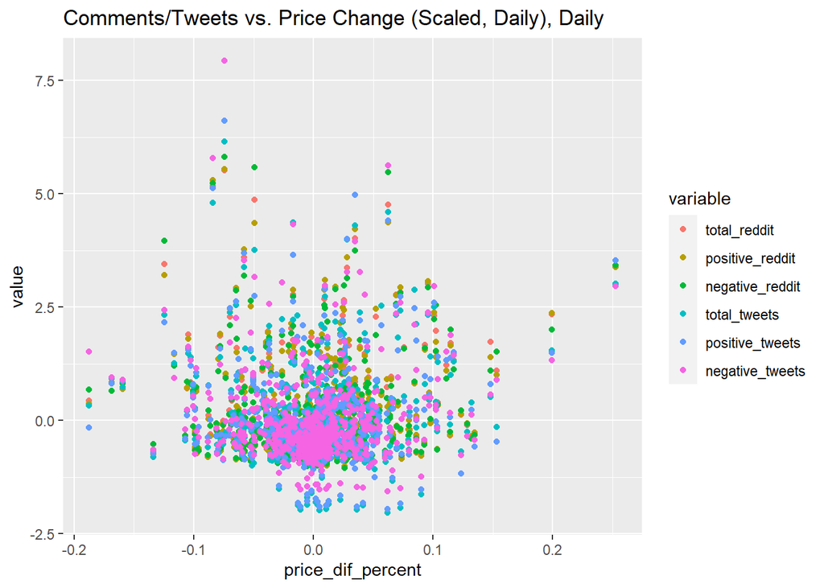

```r
#Start by shifting the close price n periods
df <- shift_df(data.daily, 1)[1:nrow(data.daily),]


cols <- c('total_reddit',
          "positive_reddit",
          'negative_reddit',
          'total_tweets',
          "positive_tweets",
          'negative_tweets')
plot_scaled_data(df, cols, 'price_dif_percent', 'Comments/Tweets vs. Price Change (Scaled, Daily), Daily', 'scatter')
```

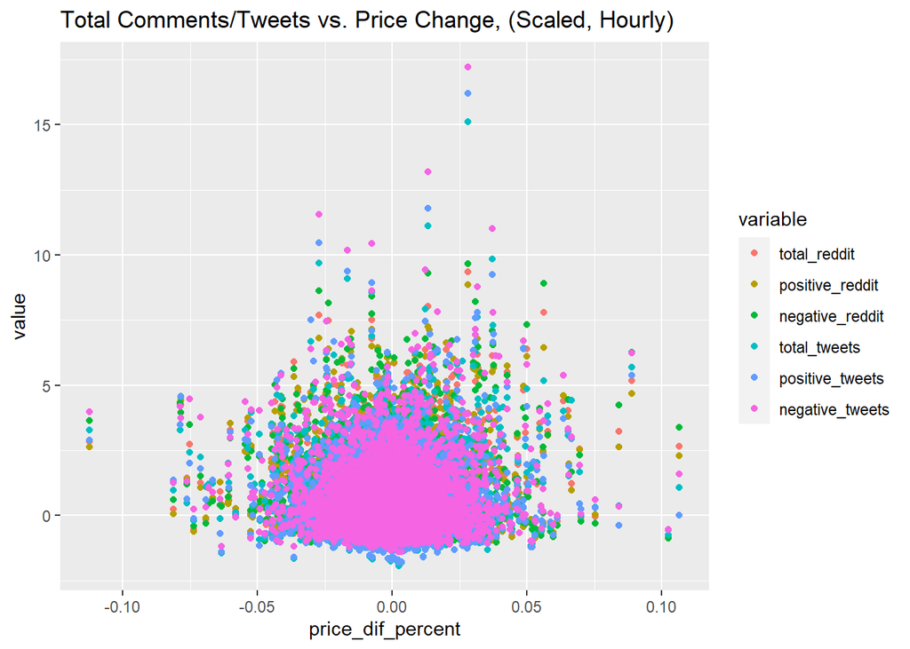

```r
df <- shift_df(data.hourly, 1)

cols <- c('total_reddit',
          "positive_reddit",
          'negative_reddit',
          'total_tweets',
          "positive_tweets",
          'negative_tweets')
plot_scaled_data(df, cols, 'price_dif_percent', 'Total Comments/Tweets vs. Price Change, (Scaled, Hourly)', 'scatter')
```